# Covid-19 Analysis

## Presentazione del Report

Analisi della situazione italiana del Covid-19 basata sui dati della Protezione Civile. I dati sono aggiornati alle 18.30 e sono recuperati dal repository https://github.com/pcm-dpc/COVID-19. Per aggiornare i dati rilanciare il presente Notebook.

> Questo Report è stato sviluppando usando Jupyter Lab un tool che permette la scrittura di codice Python tramite Browser. Il codice sorgente è disponibile all'indirizzo https://github.com/pasalino/Covid-19-PyAnalysis .

> **Sono gradite le Star (stelline in alto a destra della pagina).**  
> Sono graditi commenti e suggerimenti che potete inviare all'indirizzo pasalino@gmail.com oppure sulla pagina https://github.com/pasalino/Covid-19-PyAnalysis/issues .  
> Qui tutte le nuove funzionalità e la Roadmap del report https://pasalino.github.io/Covid-19-PyAnalysis

## Disclosure e scarico di responsabilità

Questo report non vuole sostituirsi alle fonti ufficiali, ma ne va a completamento. Non consideratelo una fonte ufficiale ma una lettura dei dati ufficiali da un punto di vista matematico. Non mi ritengo responsabile della diffusione di questo report se non nei limiti delal condivisione di pensiero atta a comprendere meglio i dati. I dati in questo report, non sono analizzati da esperti di settore e quindi proni ad errori. Potrebbero esserci errori e inesattezze nel codice che produce i dati. Attraverso la pagina sopra indicata è possibile indicarle.

## Articoli di interesse per capire i numeri

- Articolo de Il Sole 24Ore che da un senso ai numeri indicati dalla protezione civile [QUI](https://www.ilsole24ore.com/art/gli-attualmente-contagiati-e-nuovi-positivi-rebus-ogni-sera-ADGG5tF)
- Articolo del Corriere della Sera che ci da una previsione secondo Einaudi Institute for Economincs and Finance (non di settore ma nemmeno degli sprovveduti [QUI](https://www.corriere.it/economia/lavoro/20_marzo_30/coronavirus-italia-quando-si-azzereranno-contagi-previsioni-regione-regione-ae9099dc-7264-11ea-bc49-338bb9c7b205.shtml).
- Articolo in cui l'Intelligenza Artificiale prova a stimare la fine dell'epidemia [QUI](https://it-blastingnews-com.cdn.ampproject.org/c/s/it.blastingnews.com/cronaca/2020/03/in-casa-fino-a-meta-giugno-a-lavoro-da-settembre-lintelligenza-artificiale-da-le-nuove-previsioni-003100255.amp.html)

## Legenda

- **CASI TOTALI**: Il numero di casi totali riscontrati rispetto al giorno giorno prima. Include guariti e morti
- **DIFF. POSITIVI**: Il numero di casi che sono la differenza dei totali riscontrati in quel giorno meno i guariti e i morti (vedi l'articolo de Il Sole 24ore per capire)
- **ATTUALMENTE POSITIVI**: Il numero dei casi che sono attualmente contagiati

## Ultimo aggiornamento dei dati dalla protezione civile

Questa data è l'ultimo aggiornamento ai dati della protezione civile a cui si riferisce questo Report

**Sat Apr 11 18:07:44 2020 +0200**

## Dati Nazionali

### I dati di oggi

|  | CASI TOTALI | DIFF. POSITIVI | GUARITI | DECEDUTI | TOT. RICOV. | RICOVERATI | TERAPIA INT. | ISOLAME. DOM. | TOT. POSITIVI | TAMPONI |
| --- | --- | --- | --- | --- | --- | --- | --- | --- | --- | --- |
| 11-Apr-20 | 4694 | 1996 | 2079 | 619 | -214 | -98 | -116 | 2210 | 1996 | 56609 |

### I dati cumulati di oggi

|  | CASI TOTALI | TOT. POSITIVI | GUARITI | DECEDUTI | TOT. RICOV. | RICOVERATI | TERAPIA INT. | ISOLAME. DOM. | TAMPONI |
| --- | --- | --- | --- | --- | --- | --- | --- | --- | --- |
| 11-Apr-20 | 152271 | 100269 | 32534 | 19468 | 31525 | 28144 | 3381 | 68744 | 963473 |

#### Grafico della progressione giornaliera

Ogni punto indica il numero di casi evidenziati in quel giorno

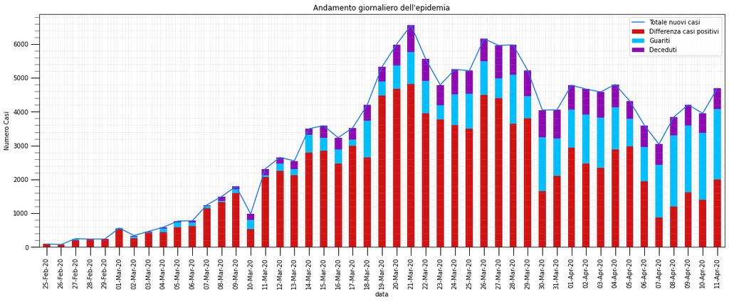

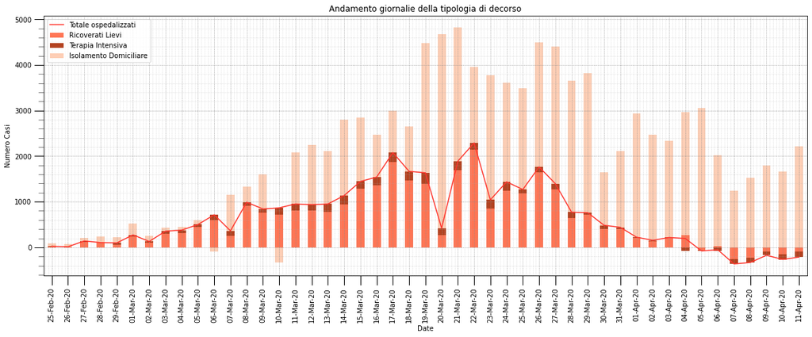

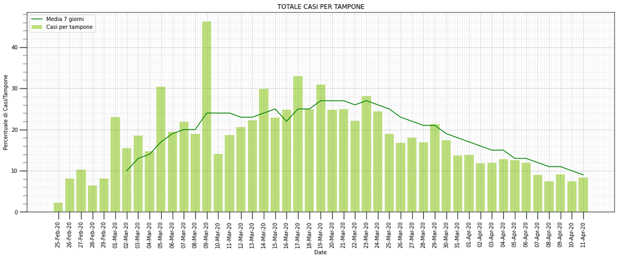

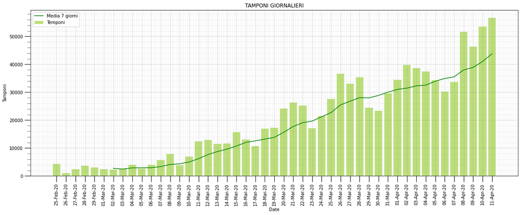

#### I dati degli ultimi 5 giorni

|  | CASI TOTALI | DIFF. POSITIVI | GUARITI | DECEDUTI | TOT. RICOV. | RICOVERATI | TERAPIA INT. | ISOLAME. DOM. | TAMPONI |
| --- | --- | --- | --- | --- | --- | --- | --- | --- | --- |
| 07-Apr-20 | 3039 | 880 | 1555 | 604 | -364 | -258 | -106 | 1244 | 33713 |
| 08-Apr-20 | 3836 | 1195 | 2099 | 542 | -332 | -233 | -99 | 1527 | 51680 |
| 09-Apr-20 | 4204 | 1615 | 1979 | 610 | -174 | -86 | -88 | 1789 | 46244 |
| 10-Apr-20 | 3951 | 1396 | 1985 | 570 | -265 | -157 | -108 | 1661 | 53495 |
| 11-Apr-20 | 4694 | 1996 | 2079 | 619 | -214 | -98 | -116 | 2210 | 56609 |

### Andamento Nazionale

I dati cumulati nei giorni. Ci da idea di come sta evolvendo l'epidemia.

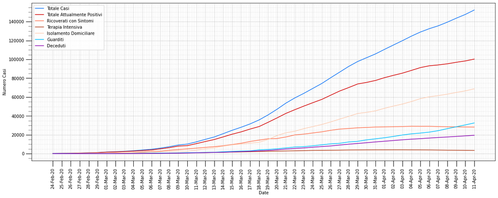

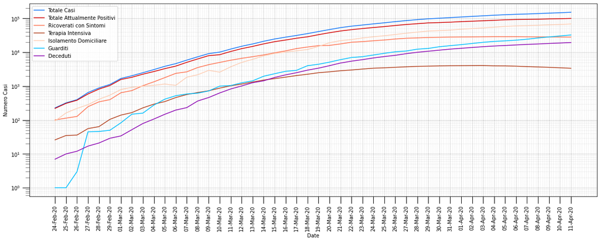

#### I dati degli ultimi 5 giorni

|  | CASI TOTALI | TOT. POSITIVI | GUARITI | DECEDUTI | TOT. RICOV. | RICOVERATI | TERAPIA INT. | ISOLAME. DOM. | TAMPONI |
| --- | --- | --- | --- | --- | --- | --- | --- | --- | --- |
| 07-Apr-20 | 135586 | 94067 | 24392 | 17127 | 32510 | 28718 | 3792 | 61557 | 755445 |
| 08-Apr-20 | 139422 | 95262 | 26491 | 17669 | 32178 | 28485 | 3693 | 63084 | 807125 |
| 09-Apr-20 | 143626 | 96877 | 28470 | 18279 | 32004 | 28399 | 3605 | 64873 | 853369 |
| 10-Apr-20 | 147577 | 98273 | 30455 | 18849 | 31739 | 28242 | 3497 | 66534 | 906864 |
| 11-Apr-20 | 152271 | 100269 | 32534 | 19468 | 31525 | 28144 | 3381 | 68744 | 963473 |

### Percentuale di crescita

Le percentuali di crescita sono valori che danno idea rispetto al giorno precedente di come si muove l'epidemia. Questi valori a causa del numero molto elevato di contagi è normale che scendano.

|  | CASI TOTALI | DIFF. POSITIVI | TOT. POSITIVI | GUARITI | DECEDUTI | TOT. RICOV. | RICOVERATI | TERAPIA INT. | ISOLAME. DOM. | TAMPONI |
| --- | --- | --- | --- | --- | --- | --- | --- | --- | --- | --- |
| 11-Apr-20 | 3.18 | 42.98 | 2.03 | 6.83 | 3.28 | -0.67 | -0.35 | -3.32 | 3.32 | 6.24 |

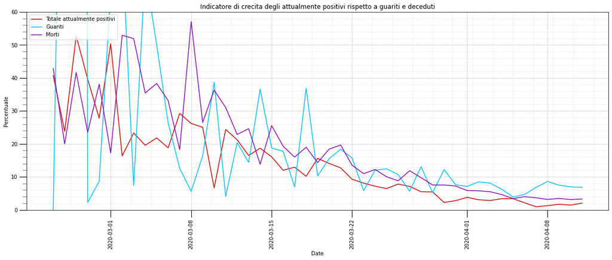

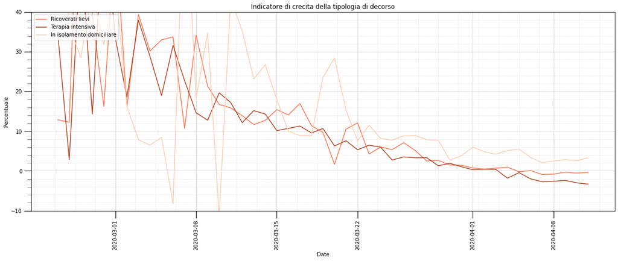

#### I dati degli ultimi 5 giorni

I valori sono in percentuale (%)

|  | CASI TOTALI | DIFF. POSITIVI | TOT. POSITIVI | GUARITI | DECEDUTI | TOT. RICOV. | RICOVERATI | TERAPIA INT. | ISOLAME. DOM. | TAMPONI |
| --- | --- | --- | --- | --- | --- | --- | --- | --- | --- | --- |
| 07-Apr-20 | 2.29 | -54.66 | 0.94 | 6.81 | 3.66 | -1.11 | -0.89 | -2.72 | 2.06 | 4.67 |
| 08-Apr-20 | 2.83 | 35.80 | 1.27 | 8.61 | 3.16 | -1.02 | -0.81 | -2.61 | 2.48 | 6.84 |
| 09-Apr-20 | 3.02 | 35.15 | 1.70 | 7.47 | 3.45 | -0.54 | -0.30 | -2.38 | 2.84 | 5.73 |
| 10-Apr-20 | 2.75 | -13.56 | 1.44 | 6.97 | 3.12 | -0.83 | -0.55 | -3.00 | 2.56 | 6.27 |
| 11-Apr-20 | 3.18 | 42.98 | 2.03 | 6.83 | 3.28 | -0.67 | -0.35 | -3.32 | 3.32 | 6.24 |

### Trends e medie

Uno spaccato di alcuni dati. Viene visualizzato anche il trend medio settimanale. GR = Growth Rate - Fattore di crescita

- **CASI TOTALI GR**: Quando questo numero sarà zero, l'epidemia si sarà fermata e dovremmo aspettare che tutti siano guariti (Sperando che nessuno infetti altri).
- **NUOVI CASI TOTALI GR**: Quando questo numero sarà zero, non ci saranno più nuovi contagi e dovremo solo aspettare che tutti guardiscano
- **TAMPONI GR**: Più è alto questo numero più sono i tamponi che stanno effettuando rispetto al giorno prima. Non può andare in negativo. Se è 0 significa che non hanno fatto tamponi rispetto al giorno prima
- **DECEDUTI**: Questo numero indica di quanto aumentano rispetto al giorno prima i morti. Se questo numero va a zero significa che non ci sono più nuovi morti.

[output not shown]

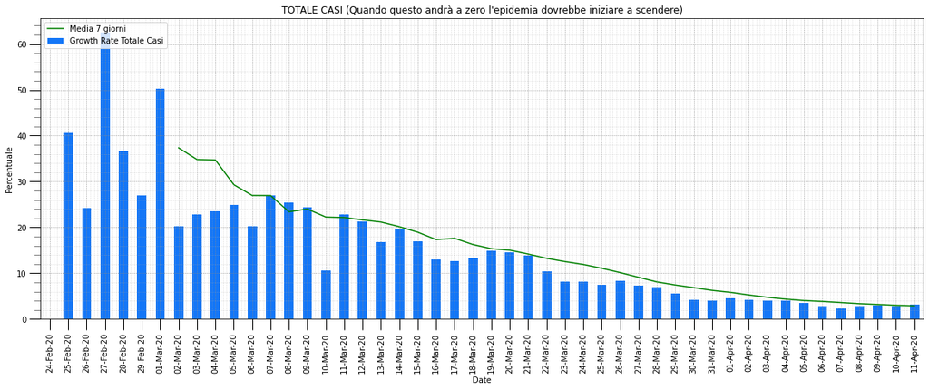

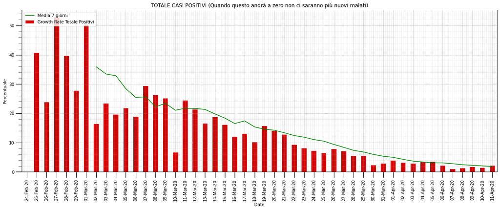

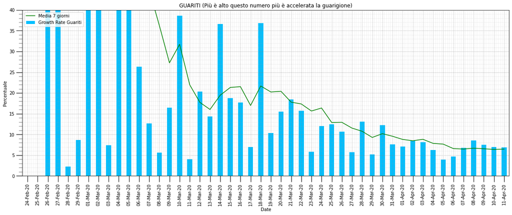

[figure not shown]

## Velocità epidemia (Growth Factor)

Calcolo della derivata. La derivata ci dà l'idea della velocità e della direzione della curva epidemica. Se il valore è uguale a 0 la crescita è lineare (ogni giorno cresce dello stesso numero di persone è come andare a una velocità fissa di 50KM orari). Un fattore maggiore di uno zero indica che la crescita aumenta la sua velocità (l'epidemia schiaccia sull'acceleratore), un valore inferiore a zero indica l'epidemia rallenta la sua velocità (l'epidemaia ha schiacciato il freno).

[output not shown]

[figure not shown]

[figure not shown]

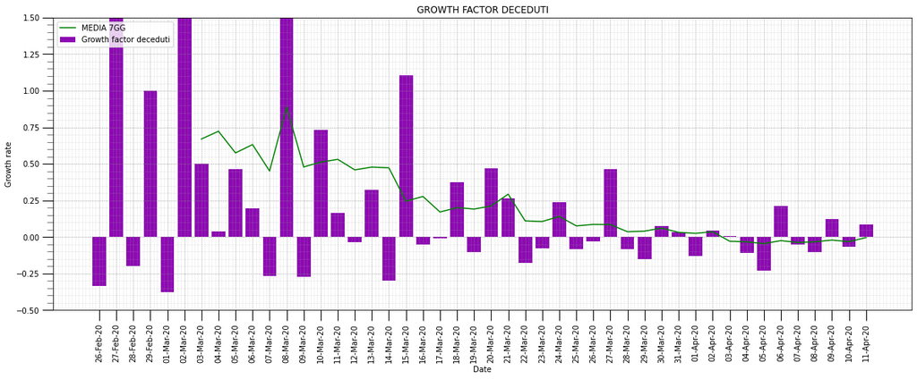

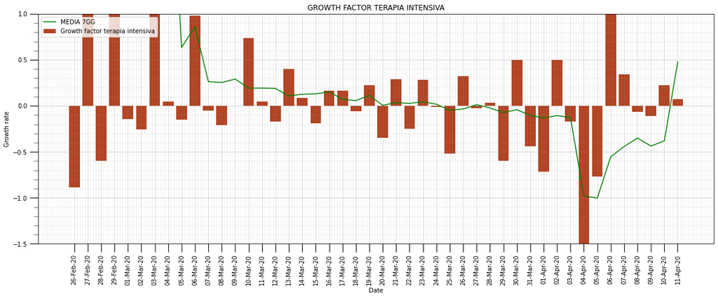

### Divisione percentuali dei casi

Un indicazione percentuale dei dati. La fotografia ad oggi (dall'inizio dell'epidemia italiana)

**Le percentuali giornaliere (dati giorno per giorno)**

|  | RICOVERATI | TER. INTENSIVA | ISOLAMENTO DOMICILIARE | GUARITI | DECEDUTI |
| --- | --- | --- | --- | --- | --- |
| 28-Mar-20 | 10.83 | 2.08 | 48.21 | 24.00 | 14.88 |
| 29-Mar-20 | 13.61 | 0.96 | 58.56 | 12.38 | 14.49 |
| 30-Mar-20 | 10.10 | 1.85 | 28.74 | 39.26 | 20.05 |
| 31-Mar-20 | 9.80 | 1.04 | 41.15 | 27.36 | 20.65 |
| 01-Apr-20 | 4.41 | 0.25 | 56.75 | 23.38 | 15.20 |
| 02-Apr-20 | 2.93 | 0.39 | 49.74 | 30.66 | 16.28 |
| 03-Apr-20 | 4.38 | 0.33 | 46.30 | 32.28 | 16.71 |
| 04-Apr-20 | 5.60 | -1.54 | 56.00 | 25.76 | 14.17 |
| 05-Apr-20 | -1.41 | -0.39 | 70.67 | 18.98 | 12.16 |
| 06-Apr-20 | 0.75 | -2.20 | 55.38 | 28.40 | 17.67 |
| 07-Apr-20 | -8.49 | -3.49 | 40.93 | 51.17 | 19.87 |
| 08-Apr-20 | -6.07 | -2.58 | 39.81 | 54.72 | 14.13 |
| 09-Apr-20 | -2.05 | -2.09 | 42.55 | 47.07 | 14.51 |
| 10-Apr-20 | -3.97 | -2.73 | 42.04 | 50.24 | 14.43 |
| 11-Apr-20 | -2.09 | -2.47 | 47.08 | 44.29 | 13.19 |

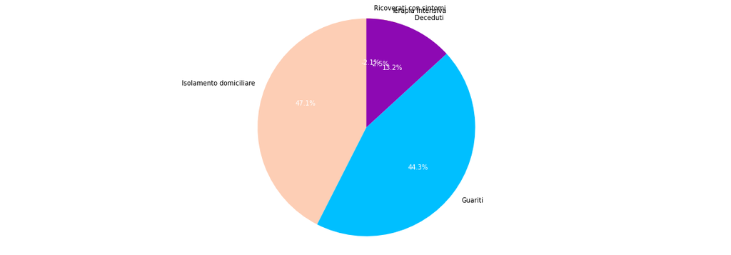

**Le percentuali dall'inizio dell'epidemia**

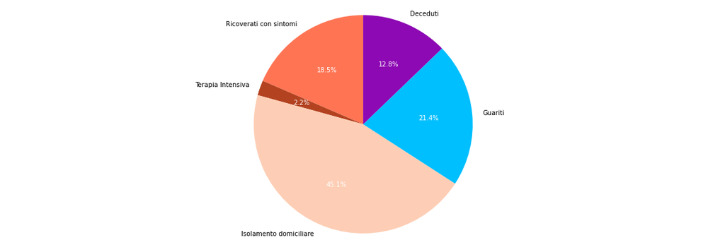

|  | RICOVERATI | TER. INTENSIVA | ISOLAMENTO DOMICILIARE | GUARITI | DECEDUTI |
| --- | --- | --- | --- | --- | --- |
| 28-Mar-20 | 28.85 | 4.17 | 42.75 | 13.39 | 10.84 |
| 29-Mar-20 | 28.03 | 4.00 | 43.60 | 13.34 | 11.03 |
| 30-Mar-20 | 27.32 | 3.91 | 43.00 | 14.37 | 11.39 |
| 31-Mar-20 | 26.65 | 3.80 | 42.93 | 14.87 | 11.75 |
| 01-Apr-20 | 25.69 | 3.65 | 43.53 | 15.24 | 11.90 |
| 02-Apr-20 | 24.77 | 3.52 | 43.78 | 15.86 | 12.07 |
| 03-Apr-20 | 23.99 | 3.39 | 43.88 | 16.49 | 12.25 |
| 04-Apr-20 | 23.28 | 3.20 | 44.35 | 16.85 | 12.33 |
| 05-Apr-20 | 22.45 | 3.08 | 45.23 | 16.92 | 12.32 |
| 06-Apr-20 | 21.86 | 2.94 | 45.50 | 17.23 | 12.47 |
| 07-Apr-20 | 21.18 | 2.80 | 45.40 | 17.99 | 12.63 |
| 08-Apr-20 | 20.43 | 2.65 | 45.25 | 19.00 | 12.67 |
| 09-Apr-20 | 19.77 | 2.51 | 45.17 | 19.82 | 12.73 |
| 10-Apr-20 | 19.14 | 2.37 | 45.08 | 20.64 | 12.77 |
| 11-Apr-20 | 18.48 | 2.22 | 45.15 | 21.37 | 12.79 |

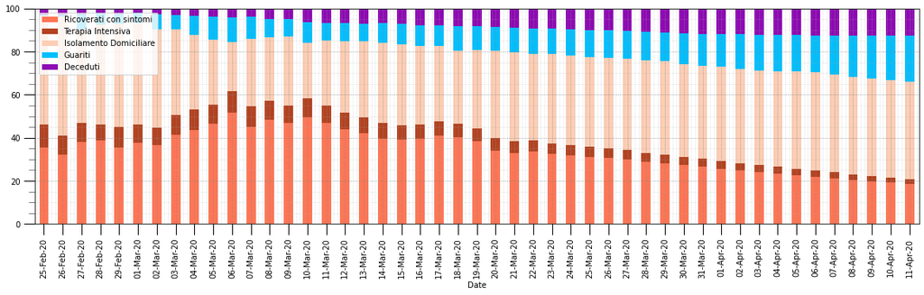

## DATI REGIONALI

> IN ARRIVO